# Chapter 6 Work With Models

```r
library(dplyr)
library(tibble)
library(ggplot2)
library(scales)
library(gapminder)
library(broom)
library(tidyr)
library(purrr)
library(margins)
library(socviz)
```

Several smoothing functions:

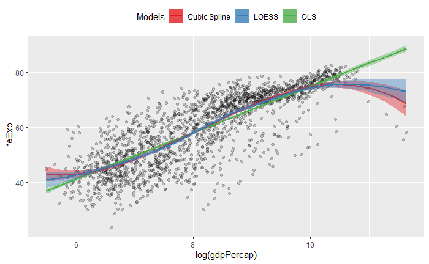

```r
model_colors <- RColorBrewer::brewer.pal(3,"Set1")
ggplot(gapminder, aes(x = log(gdpPercap), y = lifeExp)) +
  geom_point(alpha = 0.2) +
  geom_smooth(method = "lm", aes(color = "OLS", fill = "OLS")) +
  geom_smooth(method = "lm", formula = y ~ splines::bs(x, df = 3),
              aes(color = "Cubic Spline", fill = "Cubic Spline")) +
  geom_smooth(method = "loess", aes(color = "LOESS", fill = "LOESS")) +
  scale_color_manual(name="Models",values = model_colors) +
  scale_fill_manual(name="Models",values = model_colors) +
  theme(legend.position = "top")
```

## 6.1 Show several fits at once with a legend

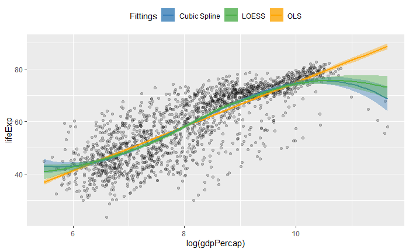

```r
#using named vector for colors
model_colors_named <- c("OLS" = "orange",
                        "Cubic Spline" = model_colors[2],
                        "LOESS" = model_colors[3])
View(model_colors_named)
ggplot(gapminder, aes(x = log(gdpPercap), y = lifeExp)) +
  geom_point(alpha = 0.2) +
  geom_smooth(method = "lm", aes(color = "OLS", fill = "OLS")) +
  geom_smooth(method = "lm", formula = y ~ splines::bs(x, df = 3),
              aes(color = "Cubic Spline", fill = "Cubic Spline")) +
  geom_smooth(method = "loess", aes(color = "LOESS", fill = "LOESS")) +
  scale_color_manual(name="Fittings",values = model_colors_named) +
  scale_fill_manual(name="Fittings",values = model_colors_named) +
  theme(legend.position = "top")
```

## 6.2 Look inside model objects

We can create a linear model object, a standard OLS regression, using the gapminder data. We use the lm() function to run the model and store it in an object called ‘out_lm’:

```r
out_lm <- lm(data = gapminder, formula = lifeExp ~ gdpPercap + pop + continent)
summary(out_lm)
```

```
Call:
lm(formula = lifeExp ~ gdpPercap + pop + continent, data = gapminder)

Residuals:
    Min      1Q  Median      3Q     Max
-49.161  -4.486   0.297   5.110  25.175

Coefficients:
                   Estimate Std. Error t value Pr(>|t|)
(Intercept)       4.781e+01  3.395e-01 140.819  < 2e-16 ***
gdpPercap         4.495e-04  2.346e-05  19.158  < 2e-16 ***
pop               6.570e-09  1.975e-09   3.326 0.000901 ***
continentAmericas 1.348e+01  6.000e-01  22.458  < 2e-16 ***
continentAsia     8.193e+00  5.712e-01  14.342  < 2e-16 ***
continentEurope   1.747e+01  6.246e-01  27.973  < 2e-16 ***
continentOceania  1.808e+01  1.782e+00  10.146  < 2e-16 ***
---
Signif. codes:  0 ‘***’ 0.001 ‘**’ 0.01 ‘*’ 0.05 ‘.’ 0.1 ‘ ’ 1

Residual standard error: 8.365 on 1697 degrees of freedom
Multiple R-squared:  0.5821,    Adjusted R-squared:  0.5806
F-statistic: 393.9 on 6 and 1697 DF,  p-value: < 2.2e-16
```

Look at the structure of the model:

```r
str(out_lm)
```

```
List of 13
 $ coefficients : Named num [1:7] 4.78e+01 4.50e-04 6.57e-09 1.35e+01 8.19 ...
  ..- attr(*, "names")= chr [1:7] "(Intercept)" "gdpPercap" "pop" "continentAmericas" ...
 $ residuals    : Named num [1:1704] -27.6 -26.1 -24.5 -22.4 -20.3 ...
  ..- attr(*, "names")= chr [1:1704] "1" "2" "3" "4" ...
 $ effects      : Named num [1:1704] -2455.1 311.1 42.6 101.1 -17.2 ...
  ..- attr(*, "names")= chr [1:1704] "(Intercept)" "gdpPercap" "pop" "continentAmericas" ...
 $ rank         : int 7
 $ fitted.values: Named num [1:1704] 56.4 56.4 56.5 56.5 56.4 ...
  ..- attr(*, "names")= chr [1:1704] "1" "2" "3" "4" ...
 $ assign       : int [1:7] 0 1 2 3 3 3 3
 $ qr           :List of 5
  ..$ qr   : num [1:1704, 1:7] -41.2795 0.0242 0.0242 0.0242 0.0242 ...
  .. ..- attr(*, "dimnames")=List of 2
  .. .. ..$ : chr [1:1704] "1" "2" "3" "4" ...
  .. .. ..$ : chr [1:7] "(Intercept)" "gdpPercap" "pop" "continentAmericas" ...
  .. ..- attr(*, "assign")= int [1:7] 0 1 2 3 3 3 3
  .. ..- attr(*, "contrasts")=List of 1
  .. .. ..$ continent: chr "contr.treatment"
  ..$ qraux: num [1:7] 1.02 1.02 1 1.01 1.04 ...
  ..$ pivot: int [1:7] 1 2 3 4 5 6 7
  ..$ tol  : num 1e-07
  ..$ rank : int 7
  ..- attr(*, "class")= chr "qr"
 $ df.residual  : int 1697
 $ contrasts    :List of 1
  ..$ continent: chr "contr.treatment"
 $ xlevels      :List of 1
  ..$ continent: chr [1:5] "Africa" "Americas" "Asia" "Europe" ...
 $ call         : language lm(formula = lifeExp ~ gdpPercap + pop + continent, data = gapminder)
 $ terms        :Classes 'terms', 'formula'  language lifeExp ~ gdpPercap + pop + continent
  .. ..- attr(*, "variables")= language list(lifeExp, gdpPercap, pop, continent)
  .. ..- attr(*, "factors")= int [1:4, 1:3] 0 1 0 0 0 0 1 0 0 0 ...
  .. .. ..- attr(*, "dimnames")=List of 2
  .. .. .. ..$ : chr [1:4] "lifeExp" "gdpPercap" "pop" "continent"
  .. .. .. ..$ : chr [1:3] "gdpPercap" "pop" "continent"
  .. ..- attr(*, "term.labels")= chr [1:3] "gdpPercap" "pop" "continent"
  .. ..- attr(*, "order")= int [1:3] 1 1 1
  .. ..- attr(*, "intercept")= int 1
  .. ..- attr(*, "response")= int 1
```

[output cut: 9 more lines]

```
  ..- attr(*, "terms")=Classes 'terms', 'formula'  language lifeExp ~ gdpPercap + pop + continent
  .. .. ..- attr(*, "variables")= language list(lifeExp, gdpPercap, pop, continent)
  .. .. ..- attr(*, "factors")= int [1:4, 1:3] 0 1 0 0 0 0 1 0 0 0 ...
  .. .. .. ..- attr(*, "dimnames")=List of 2
  .. .. .. .. ..$ : chr [1:4] "lifeExp" "gdpPercap" "pop" "continent"
  .. .. .. .. ..$ : chr [1:3] "gdpPercap" "pop" "continent"
  .. .. ..- attr(*, "term.labels")= chr [1:3] "gdpPercap" "pop" "continent"
  .. .. ..- attr(*, "order")= int [1:3] 1 1 1
  .. .. ..- attr(*, "intercept")= int 1
  .. .. ..- attr(*, "response")= int 1
  .. .. ..- attr(*, ".Environment")=<environment: R_GlobalEnv>
  .. .. ..- attr(*, "predvars")= language list(lifeExp, gdpPercap, pop, continent)
  .. .. ..- attr(*, "dataClasses")= Named chr [1:4] "numeric" "numeric" "numeric" "factor"
  .. .. .. ..- attr(*, "names")= chr [1:4] "lifeExp" "gdpPercap" "pop" "continent"
 - attr(*, "class")= chr "lm"
```

## 6.3 Get model-based graphics right

## 6.4 Generate predictions to graph

Using the functions ‘expand.grid()’ and ‘predict()’

```r
?predict
```

Using the function ‘expand.grid()’ which given a list of variables with their min/max will produce a grid of values of every combination of those variables (looking at the gapminder dataset):

```r
min_gdp <- min(gapminder$gdpPercap)
max_gdp <- max(gapminder$gdpPercap)
med_pop <- median(gapminder$pop)

pred_df <- expand.grid(
    gdpPercap = (seq(from = min_gdp, to = max_gdp, length.out = 100)),
    pop = med_pop,
    continent = c("Africa", "Americas", "Asia", "Europe", "Oceania")
  )
glimpse(pred_df)
```

```
Observations: 500
Variables: 3
$ gdpPercap <dbl> 241.1659, 1385.4282, 2529.6905, 3673.9528, 4818.2150, 5962.4773, 7106.7396, 8251.0019, 93...
$ pop       <dbl> 7023596, 7023596, 7023596, 7023596, 7023596, 7023596, 7023596, 7023596, 7023596, 7023596,...
$ continent <fct> Africa, Africa, Africa, Africa, Africa, Africa, Africa, Africa, Africa, Africa, Africa, A...
```

Now we can use the function ‘predict()’ and the above model (‘out_lm’) to calculate fitted values for every row of pred_df. Note setting ‘interval = “predict”’ calculates the 95 percent prediction intervals in addition to the point estimate.

```r
out_lm <- lm(data = gapminder, formula = lifeExp ~ gdpPercap + pop + continent)
pred_out_lm <- predict(object = out_lm, newdata = pred_df, interval = "predict")
head(pred_out_lm)
```

```
       fit      lwr      upr
1 47.96863 31.54775 64.38951
2 48.48298 32.06231 64.90365
3 48.99733 32.57670 65.41797
4 49.51169 33.09092 65.93245
5 50.02604 33.60497 66.44711
6 50.54039 34.11885 66.96193
```

We can join the columns of both ‘pred_out_lm’ and pred_df row for row:

```r
pred_df <- cbind(pred_df, pred_out_lm)
head(pred_df)
```

|  | gdpPercap | pop | continent | fit | lwr | upr |
| --- | --- | --- | --- | --- | --- | --- |
| 1 | 241.1659 | 7023596 | Africa | 47.96863 | 31.54775 | 64.38951 |
| 2 | 1385.4282 | 7023596 | Africa | 48.48298 | 32.06231 | 64.90365 |
| 3 | 2529.6905 | 7023596 | Africa | 48.99733 | 32.57670 | 65.41797 |
| 4 | 3673.9528 | 7023596 | Africa | 49.51169 | 33.09092 | 65.93245 |
| 5 | 4818.2150 | 7023596 | Africa | 50.02604 | 33.60497 | 66.44711 |
| 6 | 5962.4773 | 7023596 | Africa | 50.54039 | 34.11885 | 66.96193 |

Plot the ‘lifeExp’ from gapminder with the ‘fit’ values (using just continent = “Europe” and “Africa”). Plotting in stages. Start with plotting the linear fit lines:

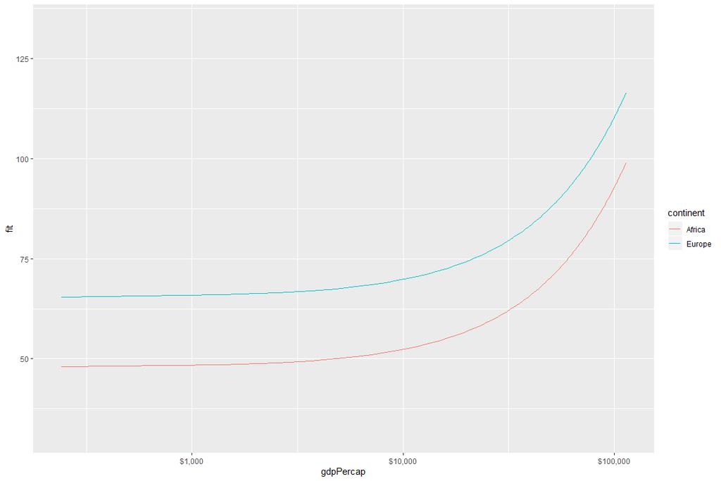

```r
plot_lm <- pred_df %>%
  filter(continent %in% c("Europe", "Africa")) %>%
  ggplot(aes(x = gdpPercap, y = fit, ymin = lwr, ymax = upr, color = continent, fill = continent, group = continent)) +
  geom_line() +
  scale_x_log10(labels = scales::dollar)
plot_lm
```

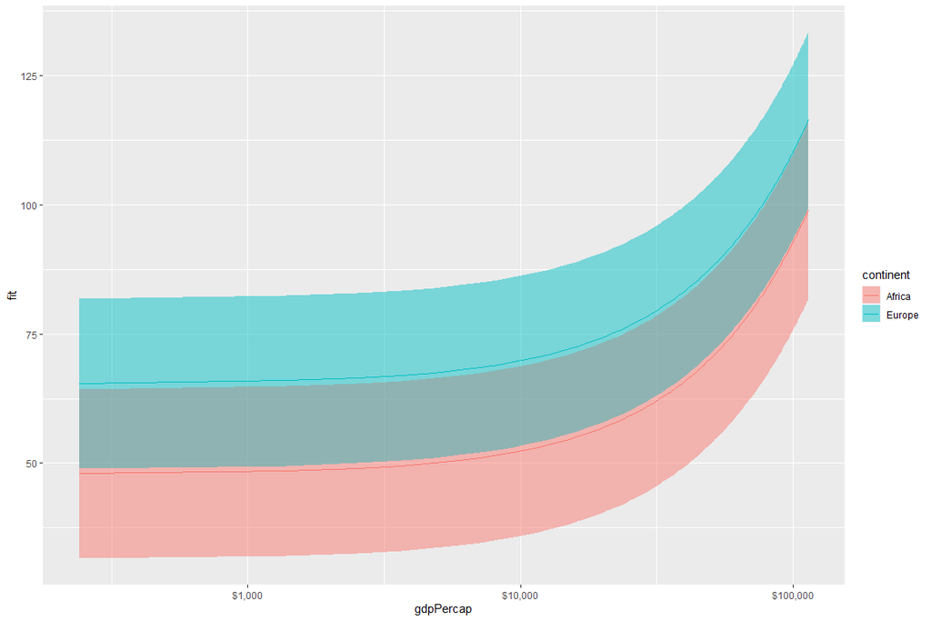

```r
plot_lm <- plot_lm +
  geom_ribbon(alpha = 0.2, color = FALSE)
plot_lm
```

Plot the original gapminder ‘gdpPercap’ vs ‘lifeExp’ as points over the fit:

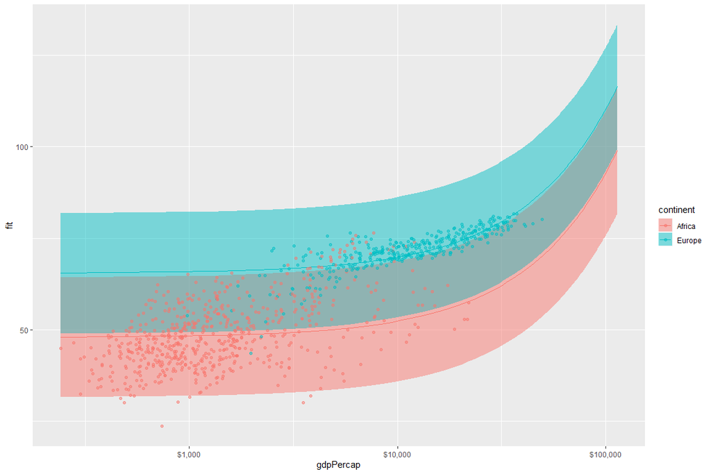

```r
gapminder_data <- gapminder %>%
  filter(continent %in% c("Europe", "Africa"))
plot_lm <- plot_lm +
  geom_point(data = gapminder_data, inherit.aes = FALSE, aes(x = gdpPercap, y = lifeExp, color = continent), alpha = 0.5)
plot_lm
```

## 6.5 Tidy model objects with Broom

The package ‘Broom’ helps us to get from the model results that R generates to numbers that we can plot. It will take model objects and turn pieces of them into data frames that you can use easily with ggplot. The generics::tidy() function turns an object into a tidy tibble:

```r
round_df <- function(x,digits = 2){
  data.frame(lapply(x,
    function(col_v) {
      if(is.numeric(col_v)) round(col_v,digits)
      else col_v
    }
  ))
}
out_lm <- lm(data = gapminder, formula = lifeExp ~ gdpPercap + pop + continent)
out_lm_tib <- generics::tidy(out_lm)
(out_lm_tib <- round_df(out_lm_tib))
```

| term | estimate | std.error | statistic | p.value |
| --- | --- | --- | --- | --- |
| (Intercept) | 47.81 | 0.34 | 140.82 | 0 |
| gdpPercap | 0.00 | 0.00 | 19.16 | 0 |
| pop | 0.00 | 0.00 | 3.33 | 0 |
| continentAmericas | 13.48 | 0.60 | 22.46 | 0 |
| continentAsia | 8.19 | 0.57 | 14.34 | 0 |
| continentEurope | 17.47 | 0.62 | 27.97 | 0 |
| continentOceania | 18.08 | 1.78 | 10.15 | 0 |

Plot the OLS estimates:

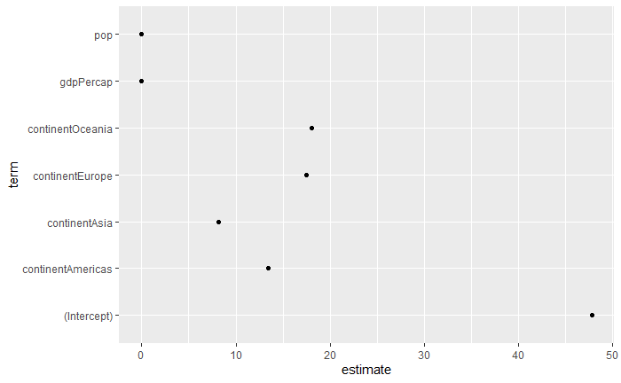

```r
out_lm_tib %>%
  ggplot(aes(term, estimate)) +
  geom_point() +
  coord_flip()
```

Add confidence intervals for the estimates:

```r
out_lm_tib <- generics::tidy(out_lm, conf.int = TRUE)
(out_lm_tib <- round_df(out_lm_tib))
```

| term | estimate | std.error | statistic | p.value | conf.low | conf.high |
| --- | --- | --- | --- | --- | --- | --- |
| (Intercept) | 47.81 | 0.34 | 140.82 | 0 | 47.15 | 48.48 |
| gdpPercap | 0.00 | 0.00 | 19.16 | 0 | 0.00 | 0.00 |
| pop | 0.00 | 0.00 | 3.33 | 0 | 0.00 | 0.00 |
| continentAmericas | 13.48 | 0.60 | 22.46 | 0 | 12.30 | 14.65 |
| continentAsia | 8.19 | 0.57 | 14.34 | 0 | 7.07 | 9.31 |
| continentEurope | 17.47 | 0.62 | 27.97 | 0 | 16.25 | 18.70 |
| continentOceania | 18.08 | 1.78 | 10.15 | 0 | 14.59 | 21.58 |

Drop the ‘intercept’ row from ‘out_lm_tidy’ and add a nice labels column:

```r
out_lm_tib <- out_lm_tib[-c(1),]
out_lm_tib$nicelabs <- c("gdpPercap","pop","Americas","Asia","Europe","Oceania")
out_lm_tib
```

|  | term | estimate | std.error | statistic | p.value | conf.low | conf.high | nicelabs |
| --- | --- | --- | --- | --- | --- | --- | --- | --- |
| 2 | gdpPercap | 0.00 | 0.00 | 19.16 | 0 | 0.00 | 0.00 | gdpPercap |
| 3 | pop | 0.00 | 0.00 | 3.33 | 0 | 0.00 | 0.00 | pop |
| 4 | continentAmericas | 13.48 | 0.60 | 22.46 | 0 | 12.30 | 14.65 | Americas |
| 5 | continentAsia | 8.19 | 0.57 | 14.34 | 0 | 7.07 | 9.31 | Asia |
| 6 | continentEurope | 17.47 | 0.62 | 27.97 | 0 | 16.25 | 18.70 | Europe |
| 7 | continentOceania | 18.08 | 1.78 | 10.15 | 0 | 14.59 | 21.58 | Oceania |

Plot the ‘estimate’ vs ‘term’ with the confidence limits:

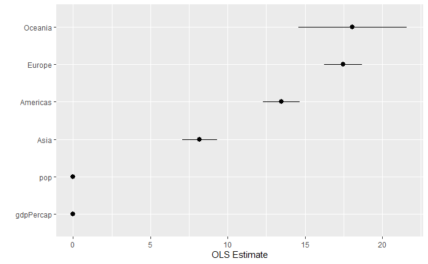

```r
ggplot(out_lm_tib, aes(x = reorder(nicelabs, estimate), y = estimate, ymin = conf.low, ymax = conf.high)) +
  geom_pointrange() +
  coord_flip() +
  labs(x = "", y = "OLS Estimate")
```

Using broom::augment() function to get additional model data. Includes all the original observations that were used to create the model along with columns for fit values and residuals. It includes only original columns used in the model:

```r
out_lm_aug_tib <- broom::augment(out_lm)
glimpse(round_df(out_lm_aug_tib))
```

```
Observations: 1,704
Variables: 11
$ lifeExp    <dbl> 28.80, 30.33, 32.00, 34.02, 36.09, 38.44, 39.85, 40.82, 41.67, 41.76, 42.13, 43.83, 55....
$ gdpPercap  <dbl> 779.45, 820.85, 853.10, 836.20, 739.98, 786.11, 978.01, 852.40, 649.34, 635.34, 726.73,...
$ pop        <dbl> 8425333, 9240934, 10267083, 11537966, 13079460, 14880372, 12881816, 13867957, 16317921,...
$ continent  <fct> Asia, Asia, Asia, Asia, Asia, Asia, Asia, Asia, Asia, Asia, Asia, Asia, Europe, Europe,...
$ .fitted    <dbl> 56.41, 56.44, 56.46, 56.46, 56.43, 56.46, 56.53, 56.48, 56.41, 56.44, 56.50, 56.65, 66....
$ .se.fit    <dbl> 0.47, 0.47, 0.47, 0.47, 0.47, 0.47, 0.47, 0.47, 0.47, 0.47, 0.47, 0.46, 0.54, 0.53, 0.5...
$ .resid     <dbl> -27.61, -26.10, -24.46, -22.44, -20.34, -18.02, -16.68, -15.66, -14.73, -14.68, -14.37,...
$ .hat       <dbl> 0, 0, 0, 0, 0, 0, 0, 0, 0, 0, 0, 0, 0, 0, 0, 0, 0, 0, 0, 0, 0, 0, 0, 0, 0, 0, 0, 0, 0, ...
$ .sigma     <dbl> 8.34, 8.34, 8.35, 8.35, 8.35, 8.36, 8.36, 8.36, 8.36, 8.36, 8.36, 8.36, 8.36, 8.37, 8.3...
$ .cooksd    <dbl> 0.01, 0.00, 0.00, 0.00, 0.00, 0.00, 0.00, 0.00, 0.00, 0.00, 0.00, 0.00, 0.00, 0.00, 0.0...
$ .std.resid <dbl> -3.31, -3.13, -2.93, -2.69, -2.44, -2.16, -2.00, -1.87, -1.76, -1.76, -1.72, -1.54, -1....
```

To include all the original columns, set the ‘data’ argument of ’augment:

```r
out_lm_aug_tib <- broom::augment(out_lm, data = gapminder)
glimpse(round_df(out_lm_aug_tib))
```

```
Observations: 1,704
Variables: 13
$ country    <fct> Afghanistan, Afghanistan, Afghanistan, Afghanistan, Afghanistan, Afghanistan, Afghanist...
$ continent  <fct> Asia, Asia, Asia, Asia, Asia, Asia, Asia, Asia, Asia, Asia, Asia, Asia, Europe, Europe,...
$ year       <dbl> 1952, 1957, 1962, 1967, 1972, 1977, 1982, 1987, 1992, 1997, 2002, 2007, 1952, 1957, 196...
$ lifeExp    <dbl> 28.80, 30.33, 32.00, 34.02, 36.09, 38.44, 39.85, 40.82, 41.67, 41.76, 42.13, 43.83, 55....
$ pop        <dbl> 8425333, 9240934, 10267083, 11537966, 13079460, 14880372, 12881816, 13867957, 16317921,...
$ gdpPercap  <dbl> 779.45, 820.85, 853.10, 836.20, 739.98, 786.11, 978.01, 852.40, 649.34, 635.34, 726.73,...
$ .fitted    <dbl> 56.41, 56.44, 56.46, 56.46, 56.43, 56.46, 56.53, 56.48, 56.41, 56.44, 56.50, 56.65, 66....
$ .se.fit    <dbl> 0.47, 0.47, 0.47, 0.47, 0.47, 0.47, 0.47, 0.47, 0.47, 0.47, 0.47, 0.46, 0.54, 0.53, 0.5...
$ .resid     <dbl> -27.61, -26.10, -24.46, -22.44, -20.34, -18.02, -16.68, -15.66, -14.73, -14.68, -14.37,...
$ .hat       <dbl> 0, 0, 0, 0, 0, 0, 0, 0, 0, 0, 0, 0, 0, 0, 0, 0, 0, 0, 0, 0, 0, 0, 0, 0, 0, 0, 0, 0, 0, ...
$ .sigma     <dbl> 8.34, 8.34, 8.35, 8.35, 8.35, 8.36, 8.36, 8.36, 8.36, 8.36, 8.36, 8.36, 8.36, 8.37, 8.3...
$ .cooksd    <dbl> 0.01, 0.00, 0.00, 0.00, 0.00, 0.00, 0.00, 0.00, 0.00, 0.00, 0.00, 0.00, 0.00, 0.00, 0.0...
$ .std.resid <dbl> -3.31, -3.13, -2.93, -2.69, -2.44, -2.16, -2.00, -1.87, -1.76, -1.76, -1.72, -1.54, -1....
```

Using the additional model data, plot fit vs residual:

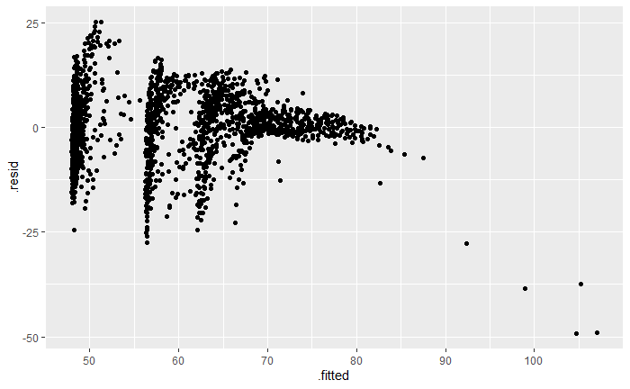

```r
ggplot(out_lm_aug_tib, aes(.fitted, .resid)) +
  geom_point()
```

Using broom::glance() function to get model-level statistics:

```r
round_df(glance(out_lm))
```

| r.squared | adj.r.squared | sigma | statistic | p.value | df | logLik | AIC | BIC | deviance | df.residual |
| --- | --- | --- | --- | --- | --- | --- | --- | --- | --- | --- |
| 0.58 | 0.58 | 8.37 | 393.91 | 0 | 7 | -6033.83 | 12083.65 | 12127.18 | 118754.5 | 1697 |

## 6.6 Grouped analysis and list columns

From gapminder, group by a specific continent and year and fit a linear model to the data:

```r
eu77_df <- gapminder %>%
  filter(continent == "Europe", year == 1977)
lm_eu77 <- lm(data = eu77_df, formula = lifeExp ~ log(gdpPercap))
summary(lm_eu77)
```

```
Call:
lm(formula = lifeExp ~ log(gdpPercap), data = eu77_df)

Residuals:
    Min      1Q  Median      3Q     Max
-7.4956 -1.0306  0.0935  1.1755  3.7125

Coefficients:
               Estimate Std. Error t value Pr(>|t|)
(Intercept)      29.489      7.161   4.118 0.000306 ***
log(gdpPercap)    4.488      0.756   5.936 2.17e-06 ***
---
Signif. codes:  0 ‘***’ 0.001 ‘**’ 0.01 ‘*’ 0.05 ‘.’ 0.1 ‘ ’ 1

Residual standard error: 2.114 on 28 degrees of freedom
Multiple R-squared:  0.5572,    Adjusted R-squared:  0.5414
F-statistic: 35.24 on 1 and 28 DF,  p-value: 2.173e-06
```

From gapminder, nest the group_by for continent and year:

```r
?tidyr::nest
gapminder_nest <- gapminder %>%
  group_by(continent, year) %>%
  tidyr::nest()
gapminder_nest
```

| continent | year | data |
| --- | --- | --- |
| Asia | 1952 |  |
| Asia | 1957 |  |
| Asia | 1962 |  |
| Asia | 1967 |  |
| Asia | 1972 |  |
| Asia | 1977 |  |
| Asia | 1982 |  |
| Asia | 1987 |  |
| Asia | 1992 |  |
| Asia | 1997 |  |

[output cut: 50 more lines]

Find ‘eu77’ in gapminder_nest:

```r
gapminder_nest %>%
  filter(continent == "Europe", year == 1977) %>%
  tidyr::unnest()
```

```
`cols` is now required.
Please use `cols = c(data)`
```

| continent | year | country | lifeExp | pop | gdpPercap |
| --- | --- | --- | --- | --- | --- |
| Europe | 1977 | Albania | 68.930 | 2509048 | 3533.004 |
| Europe | 1977 | Austria | 72.170 | 7568430 | 19749.422 |
| Europe | 1977 | Belgium | 72.800 | 9821800 | 19117.974 |
| Europe | 1977 | Bosnia and Herzegovina | 69.860 | 4086000 | 3528.481 |
| Europe | 1977 | Bulgaria | 70.810 | 8797022 | 7612.240 |
| Europe | 1977 | Croatia | 70.640 | 4318673 | 11305.385 |
| Europe | 1977 | Czech Republic | 70.710 | 10161915 | 14800.161 |
| Europe | 1977 | Denmark | 74.690 | 5088419 | 20422.901 |
| Europe | 1977 | Finland | 72.520 | 4738902 | 15605.423 |
| Europe | 1977 | France | 73.830 | 53165019 | 18292.635 |

[output cut: 20 more lines]

Create a model for each continent/year combination in gapminder:

```r
# define a function that takes a data frame and outputs a model:
fit_ols <- function(df){
  lm(lifeExp ~ log(gdpPercap), data = df)
}

year_continent_models <- gapminder %>%
  group_by(continent, year) %>%
  nest() %>%
  mutate(model = purrr::map(data, fit_ols))
year_continent_models
```

| continent | year | data | model |
| --- | --- | --- | --- |
| Asia | 1952 |  |  |
| Asia | 1957 |  |  |
| Asia | 1962 |  |  |
| Asia | 1967 |  |  |
| Asia | 1972 |  |  |
| Asia | 1977 |  |  |
| Asia | 1982 |  |  |
| Asia | 1987 |  |  |
| Asia | 1992 |  |  |
| Asia | 1997 |  |  |

[output cut: 50 more lines]

Tidy up the model column; remove the intercept term and Oceania continent:

```r
"%nin%" <- function(v1,v2) {
  !v1 %in% v2
}

?tidyr::unnest
year_continent_models <- gapminder %>%
  group_by(continent, year) %>%
  nest() %>%
  mutate(
    model = purrr::map(data, fit_ols),
    tided = purrr::map(model, generics::tidy)) %>%
  tidyr::unnest(tided) %>%
  filter(term %nin% "(Intercept)", continent %nin% "Oceania")
year_continent_models
```

| continent | year | data | model | term | estimate | std.error | statistic | p.value |
| --- | --- | --- | --- | --- | --- | --- | --- | --- |
| Asia | 1952 |  |  | log(gdpPercap) | 4.159673 | 1.2507050 | 3.325863 | 2.276623e-03 |
| Asia | 1957 |  |  | log(gdpPercap) | 4.171219 | 1.2795470 | 3.259918 | 2.707038e-03 |
| Asia | 1962 |  |  | log(gdpPercap) | 4.592523 | 1.2352003 | 3.718039 | 7.944684e-04 |
| Asia | 1967 |  |  | log(gdpPercap) | 4.501820 | 1.1532145 | 3.903714 | 4.770556e-04 |
| Asia | 1972 |  |  | log(gdpPercap) | 4.444768 | 1.0080337 | 4.409344 | 1.157584e-04 |
| Asia | 1977 |  |  | log(gdpPercap) | 4.872457 | 1.0262141 | 4.747992 | 4.417360e-05 |
| Asia | 1982 |  |  | log(gdpPercap) | 4.779256 | 0.8523760 | 5.606982 | 3.768775e-06 |
| Asia | 1987 |  |  | log(gdpPercap) | 5.174537 | 0.7267098 | 7.120500 | 5.310997e-08 |
| Asia | 1992 |  |  | log(gdpPercap) | 5.088508 | 0.6492224 | 7.837850 | 7.601869e-09 |
| Asia | 1997 |  |  | log(gdpPercap) | 5.112844 | 0.6275664 | 8.147097 | 3.351049e-09 |

[output cut: 38 more lines]

Plot the estimates for each year:

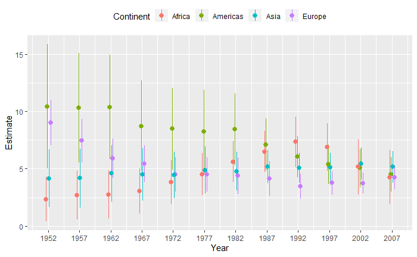

```r
ggplot(year_continent_models, aes(year, estimate, ymin = estimate - 2*std.error, ymax = estimate + 2*std.error,        group = continent, color = continent)) +
  geom_pointrange(position = position_dodge(width = 1)) +
  scale_x_continuous(breaks = unique(gapminder$year)) +
  theme(legend.position = "top") +
  labs(x = "Year", y = "Estimate", color = "Continent")
```

```r
NA
```

## 6.7 Plot marginal effects

Using margins package with the gss_sm dataset.

```r
glimpse(socviz::gss_sm)
```

```
Observations: 2,867
Variables: 32
$ year        <dbl> 2016, 2016, 2016, 2016, 2016, 2016, 2016, 2016, 2016, 2016, 2016, 2016, 2016, 2016, 20...
$ id          <dbl> 1, 2, 3, 4, 5, 6, 7, 8, 9, 10, 11, 12, 13, 14, 15, 16, 17, 18, 19, 20, 21, 22, 23, 24,...
$ ballot      <dbl> 1, 2, 3, 1, 3, 2, 1, 3, 1, 3, 2, 1, 2, 3, 2, 3, 3, 2, 2, 1, 2, 3, 2, 3, 3, 2, 1, 2, 2,...
$ age         <dbl> 47, 61, 72, 43, 55, 53, 50, 23, 45, 71, 33, 86, 32, 60, 76, 33, 56, 62, 31, 43, 58, 32...
$ childs      <dbl> 3, 0, 2, 4, 2, 2, 2, 3, 3, 4, 5, 4, 3, 5, 7, 2, 6, 5, 0, 2, 0, 3, 2, 2, 2, 8, 2, 0, 2,...
$ sibs        <dbl> 2, 3, 3, 3, 2, 2, 2, 6, 5, 1, 4, 4, 3, 6, 0, 1, 3, 8, 2, 0, 1, 4, 2, 2, 2, 7, 1, 0, 1,...
$ degree      <fct> Bachelor, High School, Bachelor, High School, Graduate, Junior College, High School, H...
$ race        <fct> White, White, White, White, White, White, White, Other, Black, White, Black, White, Bl...
$ sex         <fct> Male, Male, Male, Female, Female, Female, Male, Female, Male, Male, Female, Female, Ma...
$ region      <fct> New England, New England, New England, New England, New England, New England, New Engl...
$ income16    <fct> $170000 or over, $50000 to 59999, $75000 to $89999, $170000 or over, $170000 or over, ...
$ relig       <fct> None, None, Catholic, Catholic, None, None, None, Catholic, Protestant, None, Protesta...
$ marital     <fct> Married, Never Married, Married, Married, Married, Married, Married, Married, Married,...
```

[output cut: 19 more lines]

Relevel ‘polviews’ where “Moderate” is the reference category. Create a stats::glm model:

```r
gss_sm$polviews_m <- relevel(gss_sm$polviews, ref = "Moderate")
model_glm <- stats::glm(obama ~ polviews_m + sex*race, family = "binomial", data = gss_sm)
summary(model_glm)
```

```
Call:
stats::glm(formula = obama ~ polviews_m + sex * race, family = "binomial",
    data = gss_sm)

Deviance Residuals:
    Min       1Q   Median       3Q      Max
-2.9045  -0.5541   0.1772   0.5418   2.2437

Coefficients:
                                  Estimate Std. Error z value Pr(>|z|)
(Intercept)                       0.296493   0.134091   2.211  0.02703 *
polviews_mExtremely Liberal       2.372950   0.525045   4.520 6.20e-06 ***
polviews_mLiberal                 2.600031   0.356666   7.290 3.10e-13 ***
polviews_mSlightly Liberal        1.293172   0.248435   5.205 1.94e-07 ***
polviews_mSlightly Conservative  -1.355277   0.181291  -7.476 7.68e-14 ***
polviews_mConservative           -2.347463   0.200384 -11.715  < 2e-16 ***
polviews_mExtremely Conservative -2.727384   0.387210  -7.044 1.87e-12 ***
sexFemale                         0.254866   0.145370   1.753  0.07956 .
raceBlack                         3.849526   0.501319   7.679 1.61e-14 ***
raceOther                        -0.002143   0.435763  -0.005  0.99608
sexFemale:raceBlack              -0.197506   0.660066  -0.299  0.76477
sexFemale:raceOther               1.574829   0.587657   2.680  0.00737 **
---
Signif. codes:  0 ‘***’ 0.001 ‘**’ 0.01 ‘*’ 0.05 ‘.’ 0.1 ‘ ’ 1

(Dispersion parameter for binomial family taken to be 1)

    Null deviance: 2247.9  on 1697  degrees of freedom
Residual deviance: 1345.9  on 1686  degrees of freedom
  (1169 observations deleted due to missingness)
AIC: 1369.9

Number of Fisher Scoring iterations: 6
```

Calculate the marginal effects of each independent variable:

```r
model_gm_marginals <- margins(model_glm)
summary(model_gm_marginals)
```

|  | factor | AME | SE | z | p | lower | upper |
| --- | --- | --- | --- | --- | --- | --- | --- |
| 1 | polviews_mConservative | -0.4119 | 0.0283 | -14.5394 | 0.0000 | -0.4674 | -0.3564 |
| 2 | polviews_mExtremely Conservative | -0.4538 | 0.0420 | -10.7971 | 0.0000 | -0.5361 | -0.3714 |
| 3 | polviews_mExtremely Liberal | 0.2681 | 0.0295 | 9.0996 | 0.0000 | 0.2103 | 0.3258 |
| 4 | polviews_mLiberal | 0.2768 | 0.0229 | 12.0736 | 0.0000 | 0.2319 | 0.3218 |
| 5 | polviews_mSlightly Conservative | -0.2658 | 0.0330 | -8.0596 | 0.0000 | -0.3304 | -0.2011 |
| 6 | polviews_mSlightly Liberal | 0.1933 | 0.0303 | 6.3896 | 0.0000 | 0.1340 | 0.2526 |
| 7 | raceBlack | 0.4032 | 0.0173 | 23.3568 | 0.0000 | 0.3694 | 0.4371 |
| 8 | raceOther | 0.1247 | 0.0386 | 3.2297 | 0.0012 | 0.0490 | 0.2005 |
| 9 | sexFemale | 0.0443 | 0.0177 | 2.5073 | 0.0122 | 0.0097 | 0.0789 |

Plot the maginal effects:

```r
marginal_summary_tib <- as_tibble(summary(model_gm_marginals))
prefixes <- c("polviews_m", "sex")
marginal_summary_tib$factor <- prefix_strip(marginal_summary_tib$factor, prefixes)
marginal_summary_tib$factor <- prefix_replace(marginal_summary_tib$factor, "race", "Race:")
marginal_summary_tib %>% select(factor, AME, lower, upper)
```

| factor | AME | lower | upper |
| --- | --- | --- | --- |
| Conservative | -0.41188222 | -0.467405438 | -0.35635900 |
| Extremely Conservative | -0.45376935 | -0.536140431 | -0.37139827 |
| Extremely Liberal | 0.26805480 | 0.210318396 | 0.32579120 |
| Liberal | 0.27683785 | 0.231897478 | 0.32177822 |
| Slightly Conservative | -0.26578277 | -0.330416626 | -0.20114891 |
| Slightly Liberal | 0.19328735 | 0.133997967 | 0.25257674 |
| Race:Black | 0.40322793 | 0.369391373 | 0.43706449 |
| Race:Other | 0.12474996 | 0.049044708 | 0.20045521 |
| Female | 0.04428648 | 0.009666921 | 0.07890603 |

Plot the table:

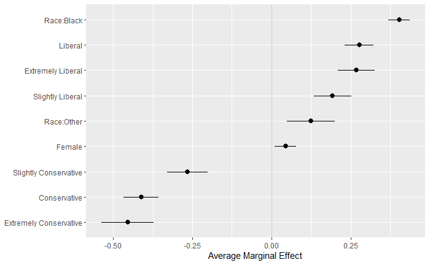

```r
ggplot(marginal_summary_tib, aes(x = reorder(factor, AME), y = AME, ymin = lower, ymax = upper)) +
  geom_hline(yintercept = 0, color = "gray80") +
  geom_pointrange() +
  coord_flip() +
  labs(x = NULL, y = "Average Marginal Effect")
```

Plot conditional effect of ‘sex’:

```r
plot_cp <- margins::cplot(model_glm, x = "sex", draw = FALSE)
```

|  | xvals | yvals | upper | lower |
| --- | --- | --- | --- | --- |
| 1 | Male | 0.5735849 | 0.6378653 | 0.5093045 |
| 2 | Female | 0.6344507 | 0.6887845 | 0.5801169 |

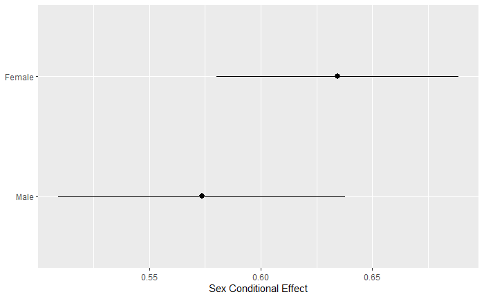

```r
ggplot(plot_cp, aes(x = reorder(xvals, yvals), y = yvals, ymin = lower, ymax = upper)) +
  geom_pointrange() +
  coord_flip() +
  labs(x = NULL, y = "Sex Conditional Effect")
```

## 6.8 Plots from complex surveys

## 6.9 Where to go next

Look at the coefplot package. It provides a quick way to produce good quality model object plots of point estimates and confidence intervals.